# Mix of Proteome benchmark — design visualization

Author

Generated to accompany Mix_of_Proteome_design.md

This notebook visualises the three-organism Mix_of_Proteome benchmark (E. coli + Human + Yeast at known proportions). Read alongside `Mix_of_Proteome_design.md`. Unlike the CSF / K562 dilution-series benchmarks, this dataset has a built-in null class (Human, 50 % in every condition) and a built-in positive class (E. coli and Yeast, varied) — no swap is needed.

```r
library(data.table)
library(dplyr)
library(ggplot2)
library(stringr)
library(tidyr)
library(patchwork)

theme_set(theme_minimal(base_size = 11))

annotation = fread("Mix_of_Proteome_annotation.csv")
idmap      = fread("idmapping.tsv")

# Load (or recompute) summarized protein-level data
sum_path = "MSstats/msstats_summarized.rda"
if (!file.exists(sum_path)) {
  library(MSstats)
  msstats_input = fread("MSstats/msstats_input.csv") |> as.data.frame()
  msstats_input$AnomalyScores = NA
  msstats_summarized = dataProcess(msstats_input,
                                   normalization  = FALSE,
                                   featureSubset  = "topN",
                                   n_top_feature  = 100,
                                   MBimpute       = TRUE,
                                   summaryMethod  = "TMP",
                                   numberOfCores  = 4)
  save(msstats_summarized, file = sum_path)
} else {
  load(sum_path)
}

prot = as.data.table(msstats_summarized$ProteinLevelData)
prot[, Protein := as.character(Protein)]
prot[, GROUP   := as.character(GROUP)]

# Attach Organism (3-class label: Human / E. coli / Yeast / NA)
org_lookup = idmap[, .(Protein = Entry,
                        Organism = fcase(
                          grepl("Homo sapiens",      Organism), "Human",
                          grepl("Escherichia coli",  Organism), "E. coli",
                          grepl("Saccharomyces|yeast", Organism, ignore.case = TRUE), "Yeast",
                          default = NA_character_))]
prot = merge(prot, org_lookup, by = "Protein", all.x = TRUE)
```

# 1. Acquisition schedule

Each row is one MS run. `Order` is injection order; `Condition` codes the mixing ratio (E.coli / Human / Yeast in %). Human is held at 50 % in every run; only E. coli (5 → 45 %) and Yeast (45 → 5 %) vary.

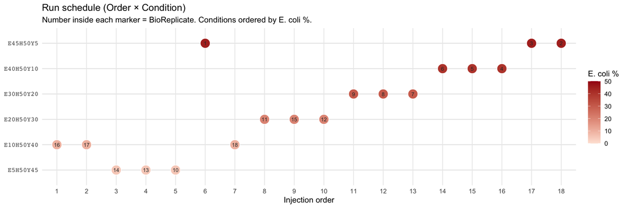

```r
ann_plot = copy(annotation)
ann_plot[, Ecoli := as.integer(str_extract(Condition, "(?<=E)[0-9]+"))]
ann_plot[, Yeast := as.integer(str_extract(Condition, "(?<=Y)[0-9]+"))]

cond_levels = ann_plot[order(Ecoli), unique(Condition)]
ann_plot[, Condition := factor(Condition, levels = cond_levels)]

ggplot(ann_plot, aes(x = Order, y = Condition, fill = Ecoli)) +
  geom_point(shape = 21, size = 6, colour = "white", stroke = 0.6) +
  geom_text(aes(label = BioReplicate), size = 2.6, colour = "grey20") +
  scale_fill_gradient(low = "#fee5d9", high = "#a50f15",
                      name = "E. coli %", limits = c(0, 50)) +
  scale_x_continuous(breaks = 1:18, expand = expansion(add = 0.5)) +
  labs(title = "Run schedule (Order × Condition)",
       subtitle = "Number inside each marker = BioReplicate. Conditions ordered by E. coli %.",
       x = "Injection order", y = NULL) +
  theme(panel.grid.major.y = element_line(colour = "grey90"),
        panel.grid.minor.x = element_blank(),
        axis.text.y = element_text(family = "mono"),
        legend.position = "right")
```

# 2. Per-protein abundance heatmap by organism

Rows are proteins (sampled to 250 per organism for legibility), columns are runs sorted by condition (E5 → E45). Each row is z-scored. Top facet = Human (expected flat across columns), middle = E. coli (expected left-to-right gradient), bottom = Yeast (expected right-to-left gradient).

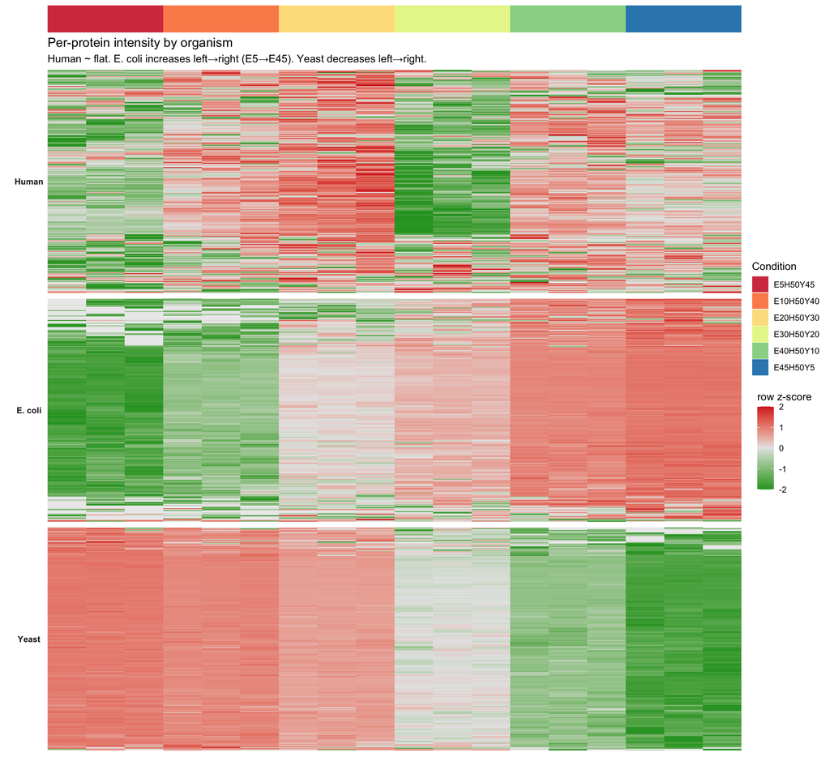

```r
run_order = ann_plot[order(Condition, Order), .(originalRUN = R.FileName, Condition)]

prot_h = prot[!is.na(Organism) & originalRUN %in% run_order$originalRUN]

# z-score per protein
prot_h[, z := scale(LogIntensities)[, 1], by = Protein]
prot_h[, z := pmax(pmin(z, 2), -2)]

# Sample 250 proteins per organism
set.seed(42)
keep_proteins = prot_h[, .(P = unique(Protein)), by = Organism][
  , .(P = sample(P, min(.N, 250))), by = Organism]
prot_h = prot_h[Protein %in% keep_proteins$P]

# Cluster rows within each organism
make_row_order = function(dat) {
  m   = dcast(dat, Protein ~ originalRUN, value.var = "z")
  pids = m$Protein
  mat = as.matrix(m[, -1, with = FALSE]); mat[is.na(mat)] = 0
  pids[if (nrow(mat) > 1) hclust(dist(mat))$order else 1]
}
ord_by_org = prot_h[, .(P = list(make_row_order(.SD))), by = Organism]
prot_h[, Protein := factor(Protein,
                            levels = unlist(ord_by_org$P))]
prot_h[, originalRUN := factor(originalRUN, levels = run_order$originalRUN)]
prot_h[, Organism := factor(Organism, levels = c("Human", "E. coli", "Yeast"))]

col_strip = run_order[, .(originalRUN = factor(originalRUN, levels = run_order$originalRUN), Condition)]
p_strip = ggplot(col_strip, aes(x = originalRUN, y = 1, fill = Condition)) +
  geom_tile() +
  scale_fill_brewer(palette = "Spectral", name = "Condition") +
  scale_x_discrete(expand = c(0, 0)) + scale_y_continuous(expand = c(0, 0)) +
  theme_void() +
  theme(legend.position = "top", plot.margin = margin(0, 0, 0, 0))

p_heat = ggplot(prot_h, aes(x = originalRUN, y = Protein, fill = z)) +
  geom_tile() +
  facet_grid(Organism ~ ., scales = "free_y", space = "free_y", switch = "y") +
  scale_fill_gradient2(low = "#2ca02c", mid = "grey90", high = "#d62728",
                       midpoint = 0, limits = c(-2, 2),
                       name = "row z-score") +
  scale_x_discrete(expand = c(0, 0)) +
  labs(title = "Per-protein intensity by organism",
       subtitle = "Human ~ flat. E. coli increases left→right (E5→E45). Yeast decreases left→right.",
       x = NULL, y = NULL) +
  theme(axis.text.x = element_blank(), axis.ticks.x = element_blank(),
        axis.text.y = element_blank(), axis.ticks.y = element_blank(),
        strip.text.y.left = element_text(angle = 0, face = "bold"),
        legend.position = "right",
        panel.spacing.y = unit(0.4, "lines"))

p_strip / p_heat + plot_layout(heights = c(0.04, 1), guides = "collect") &
  theme(legend.position = "right")
```

**What to see:**

- **Human (top).** No left/right gradient — rows are scrambled red/green noise. This is the null class.
- **E. coli (middle).** Clear gradient: green on the left (E5, E10) → red on the right (E40, E45).
- **Yeast (bottom).** Mirror of E. coli: red on the left, green on the right.

# 3. Per-protein effect size per pairwise comparison

For each of the 15 condition pairs, plot the density of `mean_log2(c1) − mean_log2(c2)` split by organism. Vertical dashed lines mark the expected log2FC for each organism in that contrast.

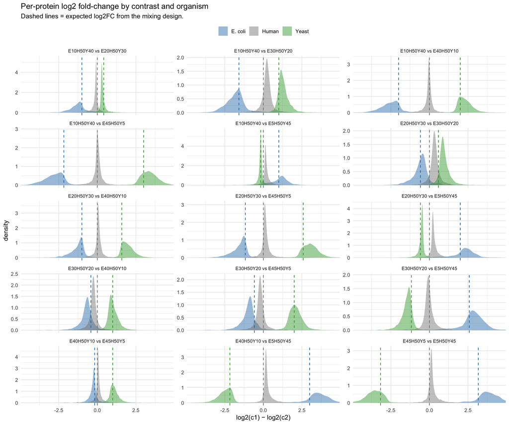

```r
# Pairwise contrasts (matches the 15 in Mixture_of_proteomes_processing.R)
cond_pct = unique(ann_plot[, .(Condition,
                                 E = Ecoli, H = 50, Y = Yeast)])
pairs_dt = CJ(c1 = cond_pct$Condition, c2 = cond_pct$Condition)[
  as.character(c1) < as.character(c2)]

pairs_dt = merge(pairs_dt, cond_pct[, .(Condition, E1 = E, Y1 = Y)],
                 by.x = "c1", by.y = "Condition")
pairs_dt = merge(pairs_dt, cond_pct[, .(Condition, E2 = E, Y2 = Y)],
                 by.x = "c2", by.y = "Condition")
pairs_dt[, `:=`(exp_Human = 0,
                 `exp_E. coli` = log2(E1 / E2),
                 exp_Yeast    = log2(Y1 / Y2))]
pairs_dt[, Contrast := paste(c1, "vs", c2)]

per_cond = prot[!is.na(GROUP), .(mean_log = mean(LogIntensities, na.rm = TRUE)),
                 by = .(Protein, GROUP)]
per_cond_w = dcast(per_cond, Protein ~ GROUP, value.var = "mean_log")

eff_long = pairs_dt[, {
  c1n = as.character(c1); c2n = as.character(c2)
  diff_vec = per_cond_w[[c1n]] - per_cond_w[[c2n]]
  data.table(Protein = per_cond_w$Protein, diff = diff_vec)
}, by = .(Contrast, c1, c2,
           exp_Human, `exp_E. coli`, exp_Yeast)]
eff_long = merge(eff_long, org_lookup, by = "Protein")
eff_long = eff_long[!is.na(Organism) & is.finite(diff)]

# Long format for expected lines
exp_long = melt(unique(pairs_dt[, .(Contrast,
                                      Human   = exp_Human,
                                      `E. coli` = `exp_E. coli`,
                                      Yeast   = exp_Yeast)]),
                id.vars = "Contrast",
                variable.name = "Organism", value.name = "expected")

ggplot(eff_long, aes(x = diff, fill = Organism)) +
  geom_density(alpha = 0.45, colour = NA) +
  geom_vline(data = exp_long,
             aes(xintercept = expected, colour = Organism),
             linetype = 2, linewidth = 0.5) +
  facet_wrap(~ Contrast, ncol = 3, scales = "free_y") +
  scale_fill_manual(values = c("Human" = "#7f7f7f",
                                "E. coli" = "#1f77b4",
                                "Yeast" = "#2ca02c")) +
  scale_colour_manual(values = c("Human" = "#7f7f7f",
                                  "E. coli" = "#1f77b4",
                                  "Yeast" = "#2ca02c"),
                      guide = "none") +
  coord_cartesian(xlim = c(-4.5, 4.5)) +
  labs(title = "Per-protein log2 fold-change by contrast and organism",
       subtitle = "Dashed lines = expected log2FC from the mixing design.",
       x = "log2(c1) − log2(c2)", y = "density", fill = NULL) +
  theme(legend.position = "top",
        strip.text = element_text(size = 8))
```